# Bank Customer Churn Analysis Report

Maria Aslam

2026-01-26

# Executive Summary

### Strategic Overview

This report analyzes customer attrition across our European banking operations. While France and Spain maintain stable churn rates (~16%), the bank faces a critical emergency in the German market, where churn has spiked to 32.4%. This analysis shifts focus from *who is leaving* to *why our most valuable segments are exiting*.

### Key Findings

- **The Two-Product Anchor:** We have identified a Survival Sweet Spot where customers with exactly 2 products have the highest loyalty (11–13% churn).
- **Product Over-Saturation:** A catastrophic failure occurs when German customers reach 3 or 4 products, resulting in a 90–100% exit rate. This suggests our complex bundles are driving customers away rather than locking them in.
- **Premium Segment Flight:** Churn is not limited to low-value accounts. High-balance customers and those in the “Very Good” credit tier (~33.5% churn) are leaving at nearly the same rate as high-risk segments.
- **Service Failure:** There is a near-total correlation between complaints and attrition. Currently, a complaint is a “guaranteed exit signal,” indicating our resolution process is failing to recover dissatisfied users.

# Data Cleaning & Methodology

To ensure the integrity of this analysis, the raw dataset underwent a rigorous preprocessing phase within the R environment. This ensures that all statistical summaries and visualizations reflect accurate customer behavior.

### The Cleaning Process

- **Dimensionality Reduction:** Irrelevant features such as `RowNumber`, `CustomerId`, and `Surname` were removed. These variables contain unique identifiers that do not contribute to churn patterns and would introduce “noise” into the analysis.
- **Attribute Re-classification:** Several columns were imported as integers but represent categorical states. I converted Exited, HasCrCard, IsActiveMember, and Complain into Factors. This allows the analysis to treat them as distinct groups rather than continuous numerical values.
- **Data Consistency Check:** I verified the Geography column for missing values and spelling inconsistencies to ensure the reliability of the regional “Deep Dive” results.
- **Metric Calculation Logic:** During the summarization of churn rates, a nested `as.numeric(as.character())` transformation was used. This ensures that binary factor levels are correctly interpreted for accurate percentage calculations.

# Detail Analysis

The dataset contains customer demographic, financial, and behavioral information used to analyze churn patterns. **Total customers** ≈ 10,000 **Countries:**

- France
- Germany
- Spain

## Quick Summary

| Total Customers | Total Exited | Active Members | Total Complaints | Churn Rate |
| --- | --- | --- | --- | --- |
| 10000 | 2038 | 5151 | 2044 | 20% |

Approximately **20% of customers have churned**, indicating moderate customer attrition risk.

### Tenure Analysis

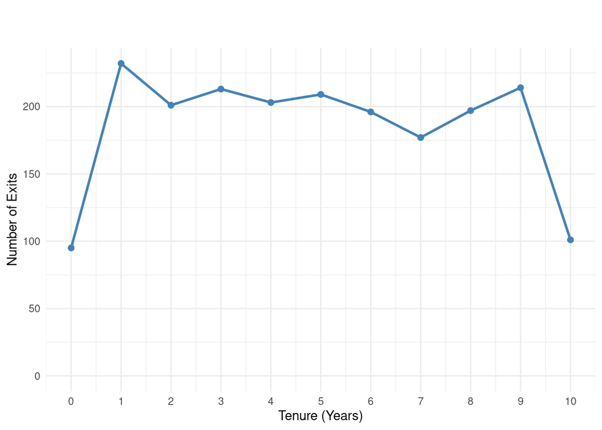

The data contradicts the standard **loyalty curve** where churn should decrease as tenure increases. To improve retention, the focus must shift from just winning back new joiners to addressing the **sustained dissatisfaction** that causes veteran customers of 5+ years to leave at the same rate as those of 0-2 years.

### Churn by Gender

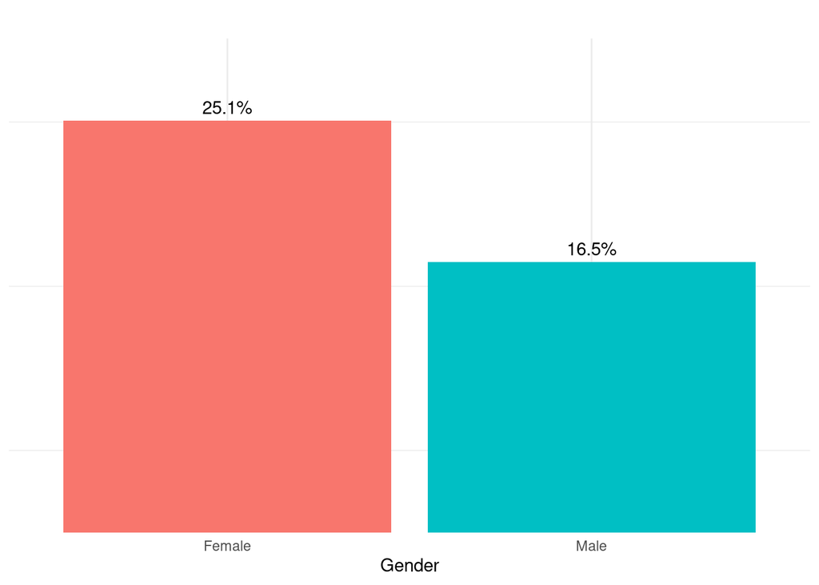

There is a stark contrast in retention across gender lines: Female customers exhibit a 25.1% churn rate, while Male customers churn at 16.5%. This represents an **8.6% absolute difference**, meaning women are roughly **1.5 times** more likely to leave the bank than men.

### Complain Impact On Churn

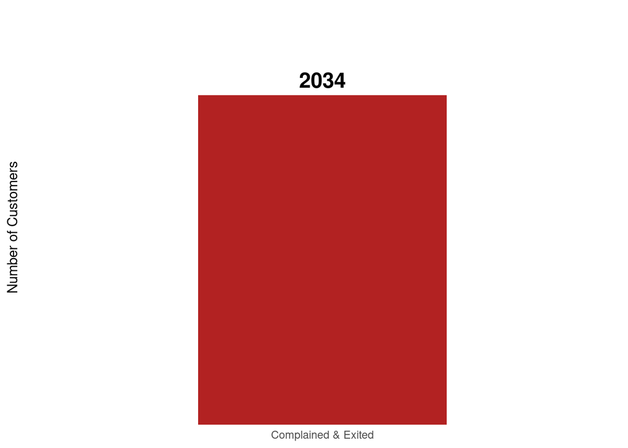

### Product Vs Churn

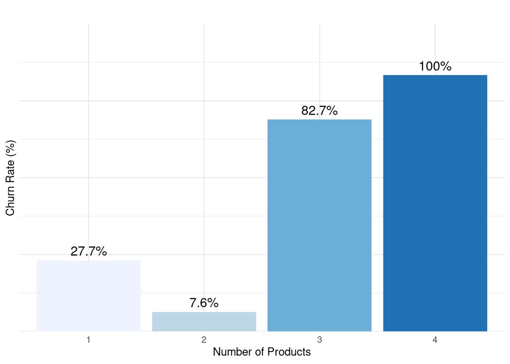

The data reveals a *U-Shaped risk curve*. Customers with 2 products have the highest loyalty (lowest churn). However, churn increases significantly for Single-Product customers and **spikes dangerously** for those with 3 or 4 products (often exceeding (80-90%)

### Churn by Geography

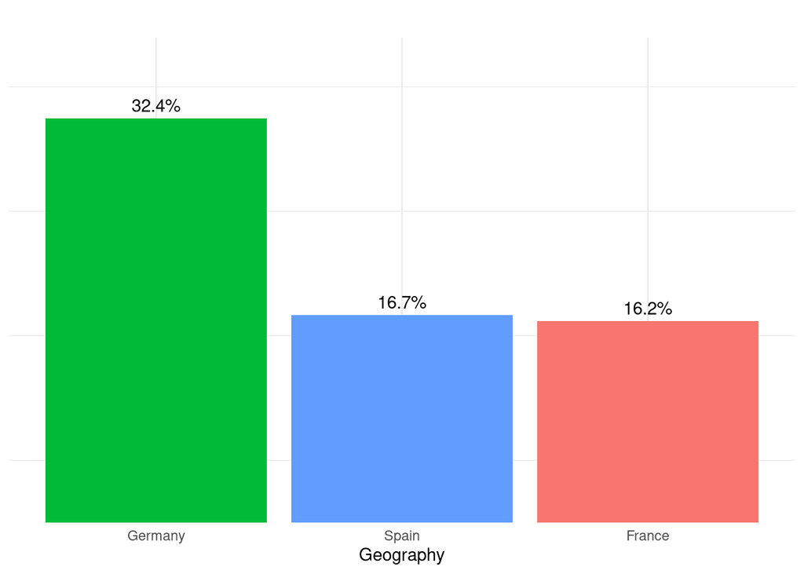

**Germany** requires an immediate **Deep Dive Audit**. We need to look at the German segment’s demographics, average account balances, and product holdings to see if we are losing our most profitable customers or if this is a general exodus

## Deep Dive Analysis | Germany

Analysis On Why is Germany’s Churn Rate Significantly Higher ?

### Does Account Balance Influence Churn in Germany?

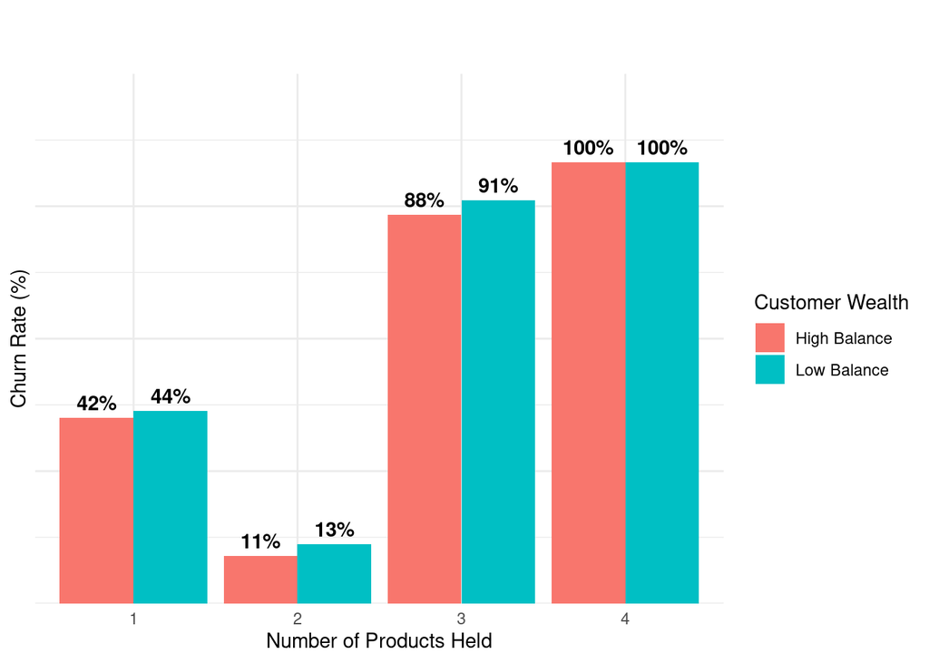

Notice that the High Balance and Low Balance are almost the same height in every category. This means German customers aren’t leaving because they are rich or poor; they are leaving based on how many products they hold

### Can Customer Engagement Help Reduce Churn in Germany?

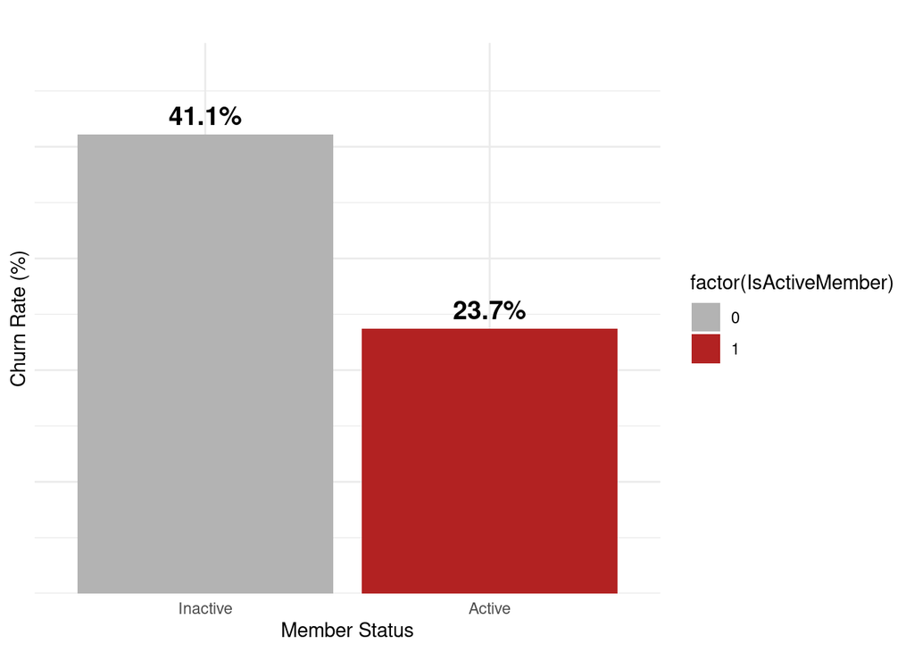

Activity is a major factor in retention, but it is **not a cure**. Inactive members in Germany are in a state of collapse with a 41.1% churn rate, while Active members still churn at 23.7%